# Regularization in R

## Fish Weight Prediction

Follow the result of Fish Weight Prediction using Linear Regression in the previous lab, now this work will apply cross validation and 3 types of regularization: Ridge, Lasso, Elastic Net. Let see if the result is improved or not when doing cross validation and regularization.

### Data Exploration

First input and see the structure of the dataset:

```r
data_fish <-  read.csv("Fish.csv")
names(data_fish)[1] = "Species"
str(data_fish)
```

```
## 'data.frame':    159 obs. of  7 variables:
##  $ Species: Factor w/ 7 levels "Bream","Parkki",..: 1 1 1 1 1 1 1 1 1 1 ...
##  $ Weight : num  242 290 340 363 430 450 500 390 450 500 ...
##  $ Length1: num  23.2 24 23.9 26.3 26.5 26.8 26.8 27.6 27.6 28.5 ...
##  $ Length2: num  25.4 26.3 26.5 29 29 29.7 29.7 30 30 30.7 ...
##  $ Length3: num  30 31.2 31.1 33.5 34 34.7 34.5 35 35.1 36.2 ...
##  $ Height : num  11.5 12.5 12.4 12.7 12.4 ...
##  $ Width  : num  4.02 4.31 4.7 4.46 5.13 ...
```

To do the linear regression in this dataset, the Species feature need to convert to dummy variables. Structure after dummy:

```r
data_fish = dummy_cols(data_fish)
data_fish = data_fish[,-1]
str(data_fish)
```

```
## 'data.frame':    159 obs. of  13 variables:
##  $ Weight           : num  242 290 340 363 430 450 500 390 450 500 ...
##  $ Length1          : num  23.2 24 23.9 26.3 26.5 26.8 26.8 27.6 27.6 28.5 ...
##  $ Length2          : num  25.4 26.3 26.5 29 29 29.7 29.7 30 30 30.7 ...
##  $ Length3          : num  30 31.2 31.1 33.5 34 34.7 34.5 35 35.1 36.2 ...
##  $ Height           : num  11.5 12.5 12.4 12.7 12.4 ...
##  $ Width            : num  4.02 4.31 4.7 4.46 5.13 ...
##  $ Species_Bream    : int  1 1 1 1 1 1 1 1 1 1 ...
##  $ Species_Parkki   : int  0 0 0 0 0 0 0 0 0 0 ...
##  $ Species_Perch    : int  0 0 0 0 0 0 0 0 0 0 ...
##  $ Species_Pike     : int  0 0 0 0 0 0 0 0 0 0 ...
##  $ Species_Roach    : int  0 0 0 0 0 0 0 0 0 0 ...
##  $ Species_Smelt    : int  0 0 0 0 0 0 0 0 0 0 ...
##  $ Species_Whitefish: int  0 0 0 0 0 0 0 0 0 0 ...
```

According to Linear Regression lab, this dataset doesn’t have misssing values, let move on to sampling.

### Stratified sampling

The sampling will divide the dataset so that 70% instanses of the dataset will go for training and 30% will go for validating

```r
str(training_set)
```

```
## 'data.frame':    111 obs. of  13 variables:
##  $ Weight           : num  242 340 450 500 450 500 500 500 340 600 ...
##  $ Length1          : num  23.2 23.9 26.8 26.8 27.6 28.5 28.7 29.1 29.5 29.4 ...
##  $ Length2          : num  25.4 26.5 29.7 29.7 30 30.7 31 31.5 32 32 ...
##  $ Length3          : num  30 31.1 34.7 34.5 35.1 36.2 36.2 36.4 37.3 37.2 ...
##  $ Height           : num  11.5 12.4 13.6 14.2 14 ...
##  $ Width            : num  4.02 4.7 4.93 5.28 4.84 ...
##  $ Species_Bream    : int  1 1 1 1 1 1 1 1 1 1 ...
##  $ Species_Parkki   : int  0 0 0 0 0 0 0 0 0 0 ...
##  $ Species_Perch    : int  0 0 0 0 0 0 0 0 0 0 ...
##  $ Species_Pike     : int  0 0 0 0 0 0 0 0 0 0 ...
##  $ Species_Roach    : int  0 0 0 0 0 0 0 0 0 0 ...
##  $ Species_Smelt    : int  0 0 0 0 0 0 0 0 0 0 ...
##  $ Species_Whitefish: int  0 0 0 0 0 0 0 0 0 0 ...
```

```r
str(test_set)
```

```
## 'data.frame':    48 obs. of  13 variables:
##  $ Weight           : num  290 363 430 390 475 600 650 575 685 680 ...
##  $ Length1          : num  24 26.3 26.5 27.6 28.4 29.4 31 31.3 31.4 31.8 ...
##  $ Length2          : num  26.3 29 29 30 31 32 33.5 34 34 35 ...
##  $ Length3          : num  31.2 33.5 34 35 36.2 37.2 38.7 39.5 39.2 40.6 ...
##  $ Height           : num  12.5 12.7 12.4 12.7 14.3 ...
##  $ Width            : num  4.31 4.46 5.13 4.69 5.1 ...
##  $ Species_Bream    : int  1 1 1 1 1 1 1 1 1 1 ...
##  $ Species_Parkki   : int  0 0 0 0 0 0 0 0 0 0 ...
##  $ Species_Perch    : int  0 0 0 0 0 0 0 0 0 0 ...
##  $ Species_Pike     : int  0 0 0 0 0 0 0 0 0 0 ...
##  $ Species_Roach    : int  0 0 0 0 0 0 0 0 0 0 ...
##  $ Species_Smelt    : int  0 0 0 0 0 0 0 0 0 0 ...
##  $ Species_Whitefish: int  0 0 0 0 0 0 0 0 0 0 ...
```

### Cross validation

As the training set is only 111 observes, the cross validation will do only 5 folds.

```r
custom <- trainControl(method = "repeatedcv",
                       number = 5,
                       repeats = 5)
options(warn=-1)
# Find the robust model
set.seed(1234)
lm_cv <- train(Weight ~ .,
            training_set,
            method = 'lm',
            trControl = custom)
```

After repeated 5 times, the robust model is:

```r
summary(lm_cv)
```

```
##
## Call:
## lm(formula = .outcome ~ ., data = dat)
##
## Residuals:
##     Min      1Q  Median      3Q     Max
## -212.91  -50.47  -14.23   38.31  259.06
##
## Coefficients: (1 not defined because of singularities)
##                   Estimate Std. Error t value Pr(>|t|)
## (Intercept)       -784.257     83.628  -9.378 2.49e-15 ***
## Length1            -62.917     42.230  -1.490  0.13943
## Length2             84.244     56.089   1.502  0.13629
## Length3             13.289     38.006   0.350  0.72734
## Height              11.584     17.621   0.657  0.51244
## Width              -12.019     29.684  -0.405  0.68643
## Species_Bream      -98.448    120.898  -0.814  0.41742
## Species_Parkki      62.615     74.270   0.843  0.40122
## Species_Perch       13.938     66.211   0.211  0.83370
## Species_Pike      -293.897     99.658  -2.949  0.00398 **
## Species_Roach       -7.001     55.613  -0.126  0.90007
## Species_Smelt      311.482     74.028   4.208 5.68e-05 ***
## Species_Whitefish       NA         NA      NA       NA
## ---
## Signif. codes:  0 '***' 0.001 '**' 0.01 '*' 0.05 '.' 0.1 ' ' 1
##
## Residual standard error: 90.9 on 99 degrees of freedom
## Multiple R-squared:  0.9449, Adjusted R-squared:  0.9388
## F-statistic: 154.3 on 11 and 99 DF,  p-value: < 2.2e-16
```

### Ridge Regression

With Ridge Regression, the model parameter will slowly go to 0. Continue using the train control above, put alpha = 0 for Ridge Regression, and 20 lamda values varies from 0.001 to 2.

```r
lm_ridge <- train(Weight ~.,
               training_set,
               method = 'glmnet',
               tuneGrid = expand.grid(alpha = 0,
                                      lambda = seq(0.001, 2, length = 20)),
               trControl = custom)
```

Summary after doing Ridge Regression:

```r
print(lm_ridge)
```

```
## glmnet
##
## 111 samples
##  12 predictor
##
## No pre-processing
## Resampling: Cross-Validated (5 fold, repeated 5 times)
## Summary of sample sizes: 87, 89, 88, 89, 91, 90, ...
## Resampling results across tuning parameters:
##
##   lambda     RMSE      Rsquared   MAE
##   0.0010000  100.6365  0.9297269  73.59322
##   0.1062105  100.6365  0.9297269  73.59322
##   0.2114211  100.6365  0.9297269  73.59322
##   0.3166316  100.6365  0.9297269  73.59322
##   0.4218421  100.6365  0.9297269  73.59322
##   0.5270526  100.6365  0.9297269  73.59322
##   0.6322632  100.6365  0.9297269  73.59322
##   0.7374737  100.6365  0.9297269  73.59322
##   0.8426842  100.6365  0.9297269  73.59322
##   0.9478947  100.6365  0.9297269  73.59322
##   1.0531053  100.6365  0.9297269  73.59322
##   1.1583158  100.6365  0.9297269  73.59322
##   1.2635263  100.6365  0.9297269  73.59322
##   1.3687368  100.6365  0.9297269  73.59322
##   1.4739474  100.6365  0.9297269  73.59322
##   1.5791579  100.6365  0.9297269  73.59322
##   1.6843684  100.6365  0.9297269  73.59322
##   1.7895789  100.6365  0.9297269  73.59322
##   1.8947895  100.6365  0.9297269  73.59322
##   2.0000000  100.6365  0.9297269  73.59322
##
## Tuning parameter 'alpha' was held constant at a value of 0
## RMSE was used to select the optimal model using the smallest value.
## The final values used for the model were alpha = 0 and lambda = 2.
```

Plot the result of ridge regression:

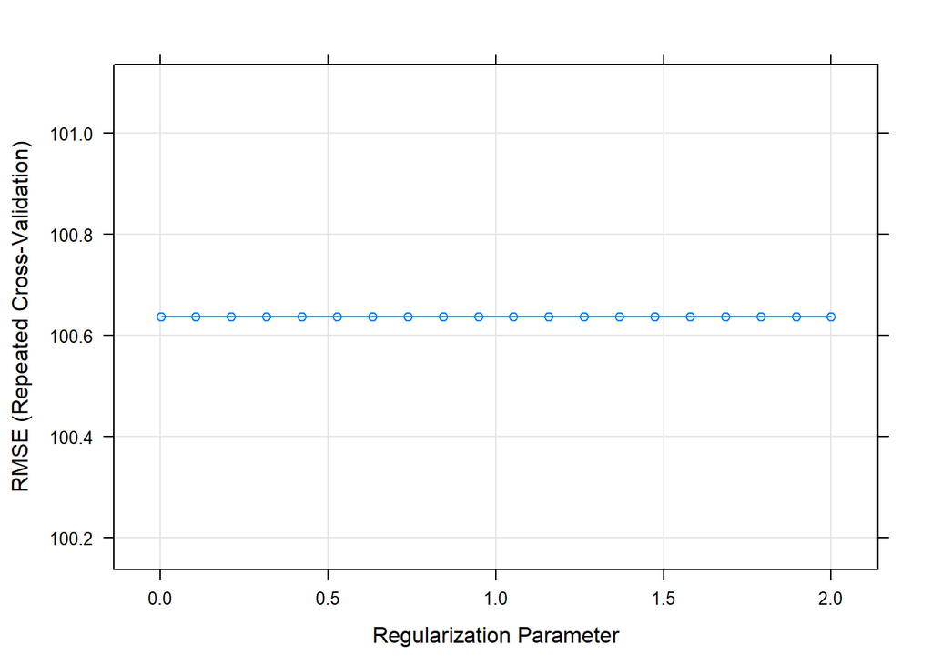

```r
plot(lm_ridge)
```

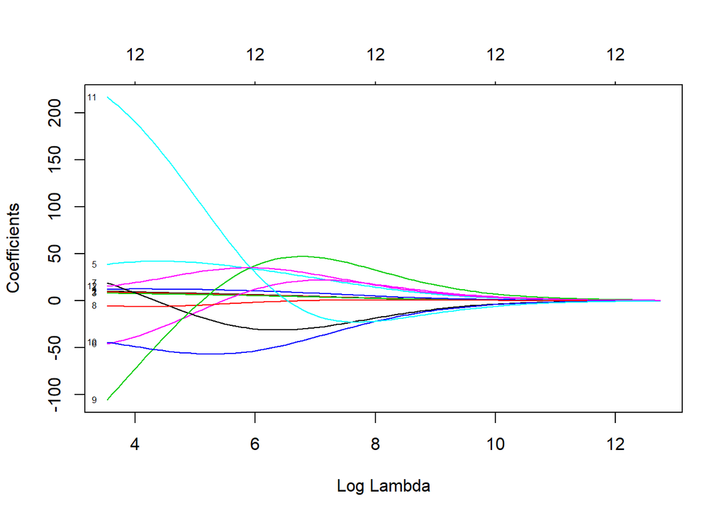

```r
plot(lm_ridge$finalModel, xvar = "lambda", label = T)
```

RMSE is unchanged when changing the lamda values in Ridge Regression.

### Lasso Regression

With Lasso Regression, the model parameter will straight go to 0. Continue using the train control above, put alpha = 1 for Lasso Regression, and 20 lamda values varies from 0.001 to 2.

```r
lm_lasso <- train(Weight ~.,
               training_set,
               method = 'glmnet',
               tuneGrid = expand.grid(alpha = 1,
                                      lambda = seq(0.001, 2, length = 20)),
               trControl = custom)
```

Summary after doing Lasso Regression:

```r
print(lm_lasso)
```

```
## glmnet
##
## 111 samples
##  12 predictor
##
## No pre-processing
## Resampling: Cross-Validated (5 fold, repeated 5 times)
## Summary of sample sizes: 90, 89, 89, 89, 87, 88, ...
## Resampling results across tuning parameters:
##
##   lambda     RMSE       Rsquared   MAE
##   0.0010000  101.51074  0.9285876  74.86242
##   0.1062105  101.31949  0.9288983  74.70388
##   0.2114211  101.05875  0.9293267  74.54640
##   0.3166316  100.84503  0.9297042  74.41648
##   0.4218421  100.64824  0.9300605  74.32468
##   0.5270526  100.46920  0.9303810  74.23729
##   0.6322632  100.30357  0.9306513  74.14608
##   0.7374737  100.15097  0.9308898  74.05693
##   0.8426842  100.01422  0.9310928  73.98183
##   0.9478947   99.92409  0.9312184  73.91874
##   1.0531053   99.88447  0.9312733  73.88432
##   1.1583158   99.86740  0.9312724  73.86879
##   1.2635263   99.88685  0.9312253  73.87629
##   1.3687368   99.90720  0.9311773  73.88111
##   1.4739474   99.93351  0.9311200  73.88702
##   1.5791579   99.97123  0.9310590  73.89557
##   1.6843684  100.01848  0.9309885  73.90578
##   1.7895789  100.06717  0.9309189  73.91850
##   1.8947895  100.11846  0.9308464  73.92845
##   2.0000000  100.17232  0.9307703  73.93738
##
## Tuning parameter 'alpha' was held constant at a value of 1
## RMSE was used to select the optimal model using the smallest value.
## The final values used for the model were alpha = 1 and lambda = 1.158316.
```

Plot the result of Lasso regression:

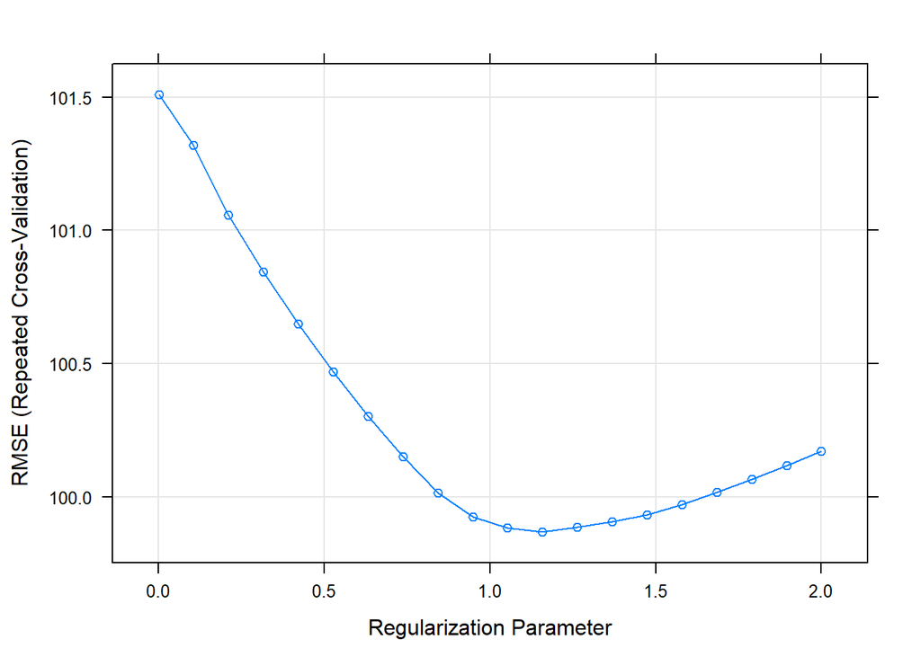

```r
plot(lm_lasso)
```

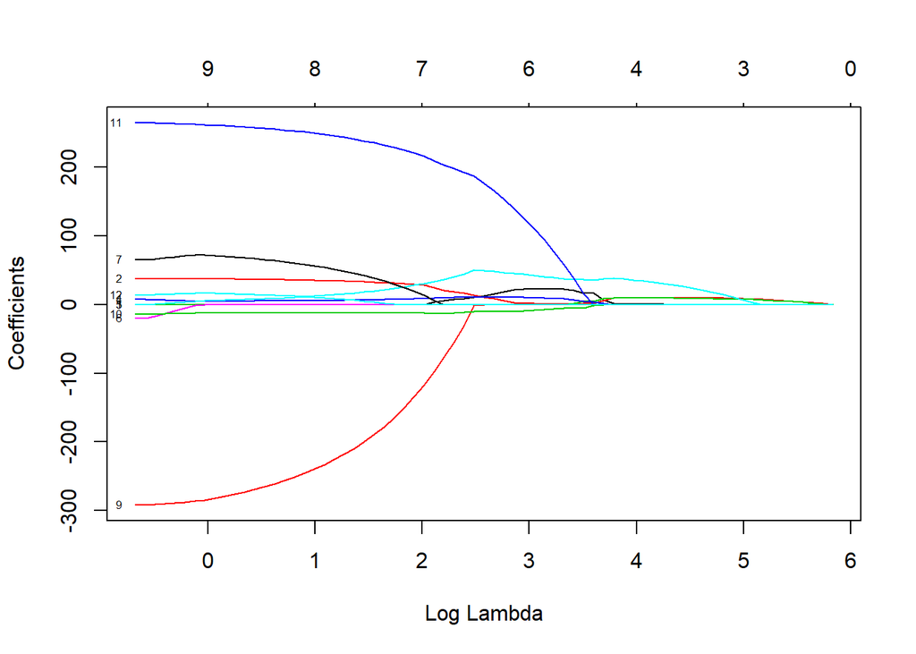

```r
plot(lm_lasso$finalModel, xvar = "lambda", label = T)
```

### Elastic Net Regression

Elastic Net Regression, is mixed between Ridge and Lasso Regression. Continue using the train control above, alpha = 1 is now also varies between 0 to 1, and 20 lamda values varies from 0.001 to 2.

```r
lm_en <- train(Weight ~.,
            training_set,
            method = 'glmnet',
            tuneGrid = expand.grid(alpha = seq (0, 1, length = 20) ,
                                   lambda = seq(0.001, 2, length = 20)),
            trControl = custom)
```

Summary after doing Entropy Net Regression:

```r
print(lm_en)
```

```
## glmnet
##
## 111 samples
##  12 predictor
##
## No pre-processing
## Resampling: Cross-Validated (5 fold, repeated 5 times)
## Summary of sample sizes: 88, 89, 89, 89, 89, 88, ...
## Resampling results across tuning parameters:
##
##   alpha       lambda     RMSE       Rsquared   MAE
##   0.00000000  0.0010000  100.68187  0.9313371  73.78635
##   0.00000000  0.1062105  100.68187  0.9313371  73.78635
##   0.00000000  0.2114211  100.68187  0.9313371  73.78635
##   0.00000000  0.3166316  100.68187  0.9313371  73.78635
##   0.00000000  0.4218421  100.68187  0.9313371  73.78635
##   0.00000000  0.5270526  100.68187  0.9313371  73.78635
##   0.00000000  0.6322632  100.68187  0.9313371  73.78635
##   0.00000000  0.7374737  100.68187  0.9313371  73.78635
##   0.00000000  0.8426842  100.68187  0.9313371  73.78635
##   0.00000000  0.9478947  100.68187  0.9313371  73.78635
##   0.00000000  1.0531053  100.68187  0.9313371  73.78635
##   0.00000000  1.1583158  100.68187  0.9313371  73.78635
##   0.00000000  1.2635263  100.68187  0.9313371  73.78635
##   0.00000000  1.3687368  100.68187  0.9313371  73.78635
##   0.00000000  1.4739474  100.68187  0.9313371  73.78635
##   0.00000000  1.5791579  100.68187  0.9313371  73.78635
##   0.00000000  1.6843684  100.68187  0.9313371  73.78635
##   0.00000000  1.7895789  100.68187  0.9313371  73.78635
##   0.00000000  1.8947895  100.68187  0.9313371  73.78635
##   0.00000000  2.0000000  100.68187  0.9313371  73.78635
##   0.05263158  0.0010000   99.82094  0.9317134  73.76431
##   0.05263158  0.1062105   99.82094  0.9317134  73.76431
##   0.05263158  0.2114211   99.82094  0.9317134  73.76431
##   0.05263158  0.3166316   99.82094  0.9317134  73.76431
##   0.05263158  0.4218421   99.82094  0.9317134  73.76431
##   0.05263158  0.5270526   99.82094  0.9317134  73.76431
##   0.05263158  0.6322632   99.82294  0.9317124  73.76584
##   0.05263158  0.7374737   99.81349  0.9317331  73.75988
##   0.05263158  0.8426842   99.79135  0.9317754  73.74890
```

[output cut: 359 more lines]

```
##   1.00000000  0.8426842   98.87290  0.9334142  73.04811
##   1.00000000  0.9478947   98.87333  0.9334372  73.02589
##   1.00000000  1.0531053   98.89689  0.9333928  73.02741
##   1.00000000  1.1583158   98.93061  0.9333311  73.03759
##   1.00000000  1.2635263   98.96854  0.9332727  73.05515
##   1.00000000  1.3687368   99.00019  0.9332252  73.07052
##   1.00000000  1.4739474   99.04118  0.9331675  73.09018
##   1.00000000  1.5791579   99.08239  0.9331062  73.10868
##   1.00000000  1.6843684   99.13281  0.9330363  73.12879
##   1.00000000  1.7895789   99.18880  0.9329606  73.15570
##   1.00000000  1.8947895   99.25208  0.9328723  73.19311
##   1.00000000  2.0000000   99.31271  0.9327908  73.22715
##
## RMSE was used to select the optimal model using the smallest value.
## The final values used for the model were alpha = 1 and lambda = 0.8426842.
```

Plot the result of Entropy Net Regression:

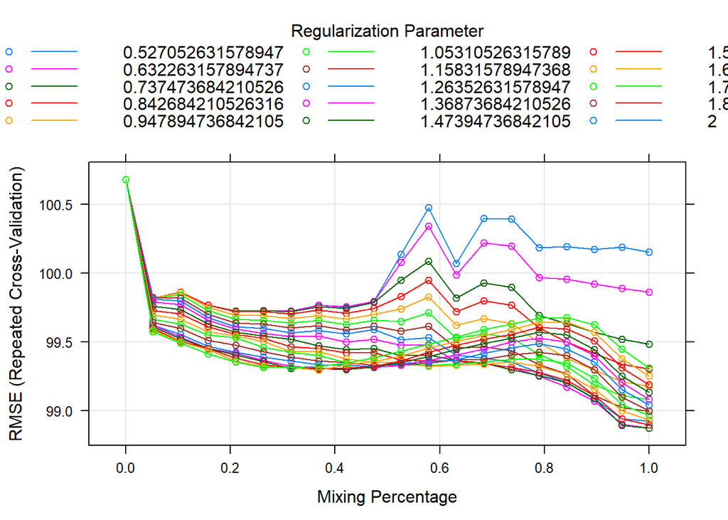

```r
plot(lm_en)
```

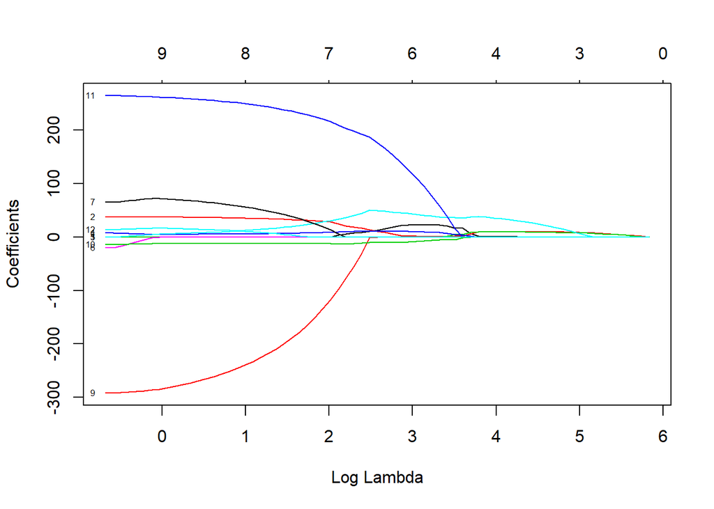

```r
plot(lm_en$finalModel, xvar = "lambda", label = T)
```

The selected model has alpha = 1 which is Lasso Regression but lambda = 0.8426842 different with the selected model when doing Lasso Regression.

### Prediction Result

#### 6.1 Previuous Result

First look at the previous result in Linear Regression lab, with basic Linear Regression only:

| RMSE On training set | RMSE On test set | RSS On training set | RSS On test set | R² On training set | R² On test set |
| --- | --- | --- | --- | --- | --- |
| 85.85008 | 104.2211 | 818096.2 | 521377.6 | 0.9448807 | 0.9010514 |

#### 6.2 With Cross Validation

```r
pred_cv_test <- predict(lm_cv, test_set)
combine_table_cv <- cbind(pred_cv_test,test_set$Weight)
colnames(combine_table_cv) <- c("Prediction Weight", "Real Weight")
combine_table_cv
```

```
##     Prediction Weight Real Weight
## 2          330.322667       290.0
## 4          444.729386       363.0
## 5          427.322380       430.0
## 8          463.600193       390.0
## 11         526.929989       475.0
## 16         569.440531       600.0
## 20         602.127787       650.0
## 21         645.489959       575.0
## 22         647.626200       685.0
## 24         710.088743       680.0
## 26         725.331985       725.0
## 31         877.757381       920.0
## 32         877.145995       955.0
## 33         905.427111       925.0
```

[output cut: 34 more lines]

| RMSE On training set | RMSE On test set | RSS On training set | RSS On test set | R² On training set | R² On test set |
| --- | --- | --- | --- | --- | --- |
| 85.85008 | 104.2211 | 818096.2 | 521377.6 | 0.9448807 | 0.9010514 |

The result is same as basic Linear Regression.

#### 6.3 Using Ridge Regression

```r
pred_ridge_test <- predict(lm_ridge, test_set)
combine_table_ridge <- cbind(pred_ridge_test,test_set$Weight)
colnames(combine_table_ridge) <- c("Prediction Weight", "Real Weight")
combine_table_ridge
```

```
##     Prediction Weight Real Weight
## 2           365.91930       290.0
## 4           440.19703       363.0
## 5           468.81232       430.0
## 8           482.28574       390.0
## 11          544.06208       475.0
## 16          603.51739       600.0
## 20          638.80835       650.0
## 21          654.51368       575.0
## 22          655.91621       685.0
## 24          703.04597       680.0
## 26          713.24839       725.0
## 31          832.06592       920.0
## 32          831.29097       955.0
## 33          888.26637       925.0
```

[output cut: 34 more lines]

| RMSE On training set | RMSE On test set | RSS On training set | RSS On test set | R² On training set | R² On test set |
| --- | --- | --- | --- | --- | --- |
| 92.16549 | 111.3147 | 942886.9 | 594766.6 | 0.936473 | 0.8871234 |

#### 6.4 Using Lasso Regression

```r
pred_lasso_test <- predict(lm_lasso, test_set)
combine_table_lasso <- cbind(pred_lasso_test,test_set$Weight)
colnames(combine_table_lasso) <- c("Prediction Weight", "Real Weight")
combine_table_lasso
```

```
##     Prediction Weight Real Weight
## 2           347.69389       290.0
## 4           450.22167       363.0
## 5           453.00187       430.0
## 8           488.54196       390.0
## 11          536.25507       475.0
## 16          582.25929       600.0
## 20          634.09429       650.0
## 21          654.97387       575.0
## 22          658.07015       685.0
## 24          697.32554       680.0
## 26          701.30910       725.0
## 31          841.35535       920.0
## 32          841.50244       955.0
## 33          884.86528       925.0
```

[output cut: 34 more lines]

| RMSE On training set | RMSE On test set | RSS On training set | RSS On test set | R² On training set | R² On test set |
| --- | --- | --- | --- | --- | --- |
| 87.14946 | 106.6483 | 843048.2 | 545945 | 0.9431996 | 0.8963889 |

The result is a bit better than using Ridge Regression, but still under the result of basic Linear Regression

#### 6.5 Using Elastic Net Regression

```r
pred_en_test <- predict(lm_en, test_set)
combine_table_en <- cbind(pred_en_test,test_set$Weight)
colnames(combine_table_en) <- c("Prediction Weight", "Real Weight")
combine_table_en
```

```
##     Prediction Weight Real Weight
## 2           345.83122       290.0
## 4           449.20287       363.0
## 5           450.64185       430.0
## 8           487.45834       390.0
## 11          535.27915       475.0
## 16          581.14974       600.0
## 20          632.99791       650.0
## 21          654.56298       575.0
## 22          658.29131       685.0
## 24          696.36842       680.0
## 26          700.76716       725.0
## 31          842.21169       920.0
## 32          842.39959       955.0
## 33          885.50806       925.0
```

[output cut: 34 more lines]

| RMSE On training set | RMSE On test set | RSS On training set | RSS On test set | R² On training set | R² On test set |
| --- | --- | --- | --- | --- | --- |
| 87.06498 | 106.6033 | 841414.6 | 545484.8 | 0.9433097 | 0.8964762 |

The result is almost similar as Lasso Regression.

### Conclusion

The result after doing cross validation, 3 types of Regularization: Ridge, Lasso, Elastic Net is still behind the basic Linear Regression. Due to the limited of number of observes this result may not reflect all the situation, however the generalizability of them will be better than the basic one.